# PA1_template

2022-07-21

**Loading and Processing the Data**

```r
library(knitr)
library(data.table)
library(dplyr)
```

```r
library(ggplot2)

activity <- read.csv("/Users/isabellademo/Desktop/Hopkins/Data Coursera/RepData_PeerAssessment1/activity.csv",
         header = TRUE)

activity$date <- as.Date(activity$date, "%Y-%m-%d")
```

**What is the mean total number of steps taken per day?**  
1. Calculate total number of steps taken per day

```r
step_sum <- aggregate(activity["steps"], by=activity["date"], sum)
```

2. Make a histogram of the total number of steps taken each day.

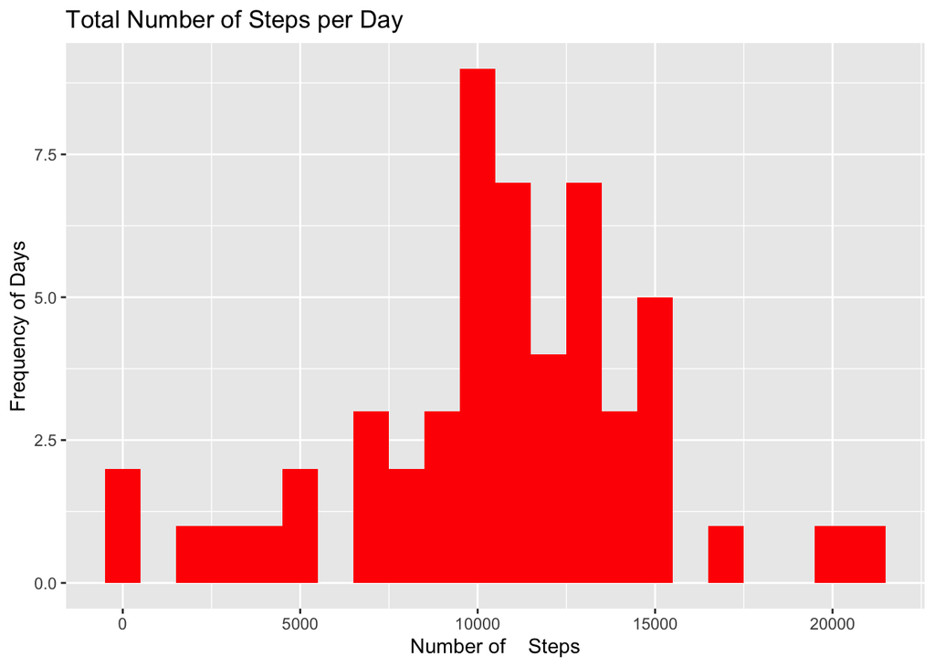

```r
ggplot(step_sum, aes(x = steps)) +
  geom_histogram(fill = "red", binwidth = 1000) +
  labs(title = "Total Number of Steps per Day", x = "Number of    Steps", y = "Frequency of Days")
```

3. Calculate and report the mean and median of the total number of steps per day.

```r
mean(step_sum$steps, na.rm = TRUE)
```

```
## [1] 10766.19
```

```r
median(step_sum$steps, na.rm = TRUE)
```

```
## [1] 10765
```

**What is the average daily activity pattern?**  
1. Make a time serires plot of the 5- minute interval and average number of steps taken.

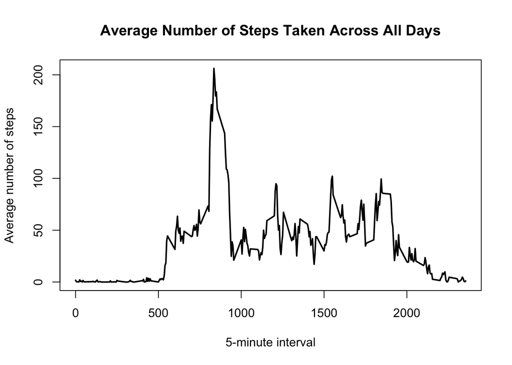

```r
avg_step <- aggregate(steps ~ interval, data = activity, mean, na.rm = TRUE)

plot(avg_step$interval, avg_step$steps, type = "l", lwd = 2,
     main = "Average Number of Steps Taken Across All Days",
     xlab = "5-minute interval", ylab = "Average number of steps")
```

2. Which 5-minute interval contains the maximum number of steps?

```r
avg_step$interval[which.max(avg_step$steps)]
```

```
## [1] 835
```

**Imputing Missing Values**  
1. Calculate and report total number of missing values.

```r
sum(is.na(activity))
```

```
## [1] 2304
```

2 and 3. Devise a strategy for filling in missing values. Create a new dataset that is equal to the original with missing data filled in.

```r
full_df <- activity
full_df[is.na(full_df)] = avg_step$steps
```

4. Make a histogram of the total number of steps taken each day. Calculate and report the mean and median total number of steps taken per day.

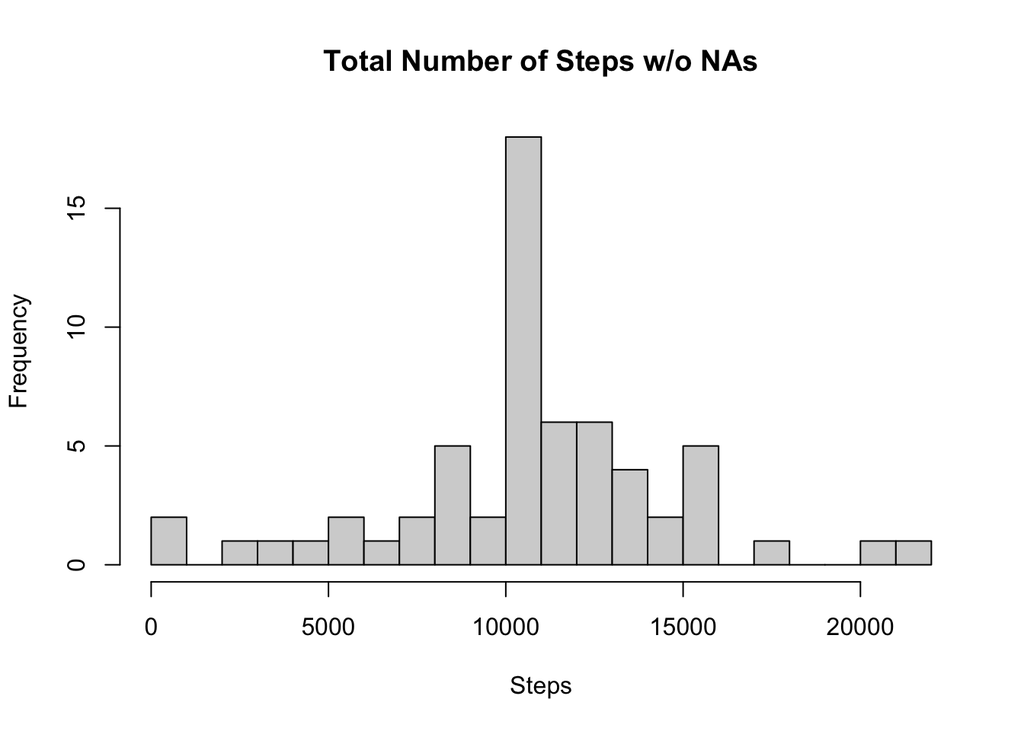

```r
total_steps_full <- aggregate(steps ~ date, data = full_df, sum, na.rm = TRUE)
hist(total_steps_full$steps, breaks = 20,
     main = "Total Number of Steps w/o NAs",
     xlab = "Steps", ylab = "Frequency")
```

```r
mean(total_steps_full$steps)
```

```
## [1] 10766.19
```

```r
median(total_steps_full$steps)
```

```
## [1] 10766.19
```

**Are there differences in activity patterns between weekdays and weekends?**  
1. Create a new factor variable in the dataset with two levels–“weekday and”weekend”

```r
full_df$day <- weekdays(full_df$date)
full_df$week <- weekdays(full_df$date)
full_df[full_df$day == "Saturday" | full_df$day == "Sunday",]$week <- "weekend"
full_df[!full_df$day == "Saturday" | full_df$day == "Sunday",]$week <- "weekday"
full_df$week <- as.factor(full_df$week)
```

2. Make a panel plot containing a time series plot of the 5-minute interval and the average number of steps taken across all weekdays or weekends.

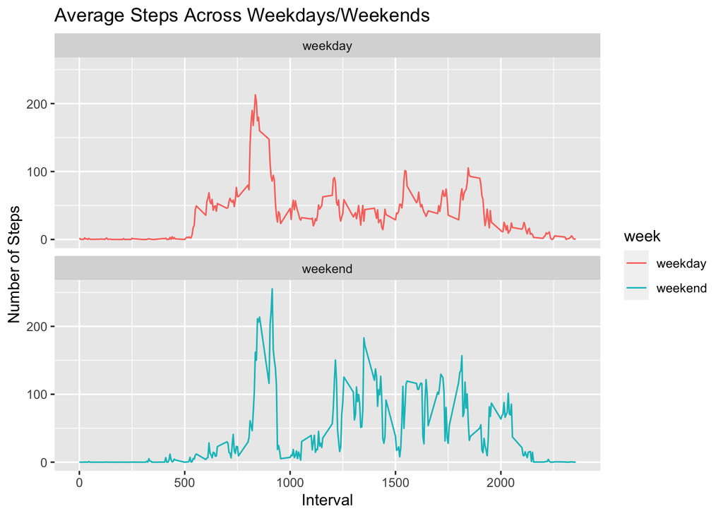

```r
library(ggplot2)
last_df <- aggregate(steps ~ interval + week, data = full_df, mean)
ggplot(last_df, aes(x = interval , y = steps, color= week)) +
  geom_line() + labs(title = "Average Steps Across Weekdays/Weekends",
                     x = "Interval", y = "Number of Steps") +
  facet_wrap(~ week , ncol = 1, nrow=2)
```